# Merging 1992-2017 Police Data with 2018 Data

Angel Mendiola Ross

5/6/2020

#1.0 Setup

```r
knitr::opts_knit$set(root.dir = '/Users/angelmr/ps239t-final-project/')
```

```r
### Clear global environment
rm(list=ls())

# Set working directory
getwd()
```

```
## [1] "/Users/angelmr/ps239t-final-project"
```

```r
# install.packages("readxl") # Needed this for reading in xlsx files which is how the state provides raw data
# install.packages("DataCombine") # Needed this for the slide function to lad/lead variables
library(pacman)
pacman::p_unload(all)
```

```
## The following packages have been unloaded:
## pacman
```

```r
pacman::p_load(
  tidyverse, #dplyr, readr, etc.
  plyr, #for editing factor levels
  magrittr, #%<>% operator
  readxl, #for excel workbooks
  tidyr, #to transform from wide to long
  ggplot2, #for plotting
  DataCombine, # for lagging and leading variables
  ggthemes # for pretty charts
)
```

Note: The 2003-2018 data came with a lot more variables (e.g. federal transfers, community development, housing, transportation expenditures, etc.). The 1992-2017 data only has police expenditures.

```
## # A tibble: 6 x 23
##   city_name  year entity_id.x total_expend total_rev police_total
##   <chr>     <dbl>       <dbl>        <dbl>     <dbl>        <dbl>
## 1 Adelanto   2016        1128     23692799  14565863      5300217
## 2 Agoura H…  2016        1129     31218079  28100766      4106157
## 3 Alameda    2016        1130    200513189 215187532     28981569
## 4 Albany     2016        1131     31910800  35120955      5948514
## 5 Alhambra   2016        1132    108343335 115993675     25941842
## 6 Aliso Vi…  2016        8635     19092520  20608025      7154514
## # … with 17 more variables: public_safety_expend <dbl>, gen_gov_expend <dbl>,
## #   transport_expend <dbl>, comm_dev_expend <dbl>, health_expend <dbl>,
## #   culture_expend <dbl>, total_fines_rev <dbl>, penalties_rev <dbl>,
## #   vehicle_fines <dbl>, total_tax_rev <dbl>, sales_tax_rev <dbl>,
## #   in_lieu_sales_tax <dbl>, prop_tax_rev <dbl>,
## #   prop_tax_in_lieu_vehicle <dbl>, cdbg <dbl>, total_fed_rev <dbl>,
## #   total_county_rev <dbl>
```

```
## # A tibble: 6 x 4
##    year City       County  police_total
##   <dbl> <chr>      <chr>   <chr>
## 1  1992 Alameda    Alameda 11681055
## 2  1992 Albany     Alameda 2227208
## 3  1992 Berkeley   Alameda 27396759
## 4  1992 Dublin     Alameda 2758067
## 5  1992 Emeryville Alameda 3907604
## 6  1992 Fremont    Alameda 21475225
```

Now that I have the two files loaded, I want to strip down the city_fin_data to the variables I will be focusing on in the anaysis then add the appropriate columns to the police_long data to prepare for rbind.

```r
# stripping down city_fin_data to just policing data for 2018 (it seems that the police_long dataset is more complete)
police_18 <- city_fin_data %>%
  subset(year==2018) %>%
  select(year,city_name,police_total)

# renaming city variable
police_long %<>% dplyr::rename(city_name = City)

# removing county variable
police_long <- police_long[-c(3)]
```

Now I am ready to combine the datasets with an rbind.

```r
# getting rid of columns not going into my analysis of city police spending
city_fin_small <- city_fin_data[c(2,1,3:5,7,13,16,17,19,22)]

names(city_fin_small) # now city_fin_small is down to 11 vars and ready to join with police data later
```

```
##  [1] "year"                 "city_name"            "entity_id.x"
##  [4] "total_expend"         "total_rev"            "public_safety_expend"
##  [7] "total_fines_rev"      "total_tax_rev"        "sales_tax_rev"
## [10] "prop_tax_rev"         "total_fed_rev"
```

```r
# creating a new data frame with the complete data
policing_complete <- rbind(police_long, police_18)

# now joining with the rest of the city financial data
policing_complete <- left_join(x=policing_complete,
                           y=city_fin_small,
                           by=c("year", "city_name"))

# saving complete policing data
save(policing_complete,
     file = "data/policing_complete.RData")
```

## 1.2 Looking at the combined dataset

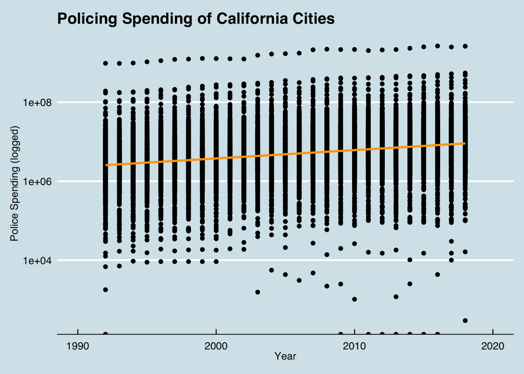

```r
# assigning police_total as numerical
policing_complete$police_total <- as.numeric(as.character(policing_complete$police_total))

# plotting the policing variable
ggplot(policing_complete, aes(x = year, y = police_total)) +
  geom_point() +
  geom_smooth(method = "lm", color = "orange") +
  scale_y_log10() +
  xlim(1990, 2020) +
  ggtitle("Policing Spending of California Cities") +
  labs(y="Police Spending (logged)", x = "Year") +
  theme_economist() +
  scale_colour_economist()
```

```r
# Save plot
ggsave(filename="plots/police_spending.pdf")
# looking at the mean and median
policing_complete %>%
  dplyr::group_by(year) %>%
  dplyr::summarise(mean_police = mean(police_total, na.rm = T),
            median_police = median(police_total, na.rm = T))
```

```
## # A tibble: 27 x 3
##     year mean_police median_police
##    <dbl>       <dbl>         <dbl>
##  1  1992    8747252.      2672355
##  2  1993    8949851.      2808382
##  3  1994    9115474.      2859206.
##  4  1995    9611983.      3070614
##  5  1996   10132028.      3149517
##  6  1997   10540394.      3227024.
##  7  1998   11082092.      3424042
##  8  1999   11582200.      3568916
##  9  2000   11966994.      3803579
## 10  2001   12392518.      4025987
## # … with 17 more rows
```

## 1.3 Adjusting my main varables of interest for inflation

I need to adjust both police spending (dependent variable) and federal transfers (independent variable) for inflation.

But I found a California-specific CPI (even better because my analysis is CA-focused) from the State’s EDD at the following website: https://www.labormarketinfo.edd.ca.gov/cgi/databrowsing/localAreaProfileQSMoreResult.asp?viewAll=&viewAllUS=&currentPage=&currentPageUS=&sortUp=&sortDown=Year&criteria=consumer+price+index&categoryType=economicindicators&geogArea=0601000000&timeseries=consumer+price+indexTimeSeries&more=&menuChoice=localAreaPro&printerFriendly=&BackHistory=-1&goTOPageText=&USgoTOPage=

I downloaded the data, which comes with California and US CPI values and created a second sheet in the file with just the California data.

```
## # A tibble: 482 x 1
##    base_cpi
##       <dbl>
##  1     272.
##  2     272.
##  3     272.
##  4     272.
##  5     272.
##  6     272.
##  7     272.
##  8     272.
##  9     272.
## 10     272.
## # … with 472 more rows
```

```
## # A tibble: 10 x 4
##     year city_name     police_total police_infl_adj
##    <dbl> <chr>                <dbl>           <dbl>
##  1  1993 Colton             6432560       11732748.
##  2  2015 Palo Alto         37180838       40592061.
##  3  2004 Mission Viejo     11268408       15714643.
##  4  2018 San Clemente      14820376       14820376
##  5  1999 Ridgecrest         2956737        4781667.
##  6  2010 Red Bluff          3941769        4733945.
##  7  2007 Orange Cove         672488         842930.
##  8  2010 Agoura Hills       3576728        4295542.
##  9  1994 Suisun City        1990936        3581057.
## 10  2004 Clearlake          2119628        2955981.
```

Now I’d like to plot the main dependent variable (the natural logarithm of inflation-adjusted policing spending) and save my plot.

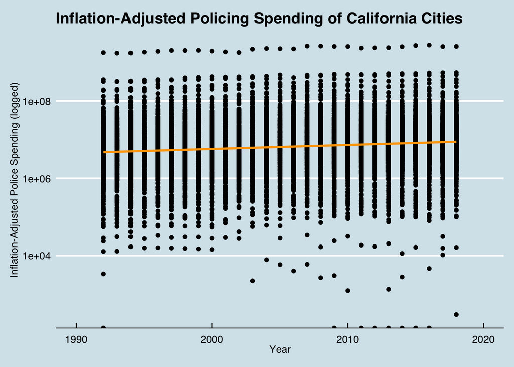

We already see that adjusting for inflation (via the California CPI) leads to a much less pronounced average increase in police spending from 1992 to 2018. Let’s check summary statistics.

```r
# checking change over time for summary variables
policing_complete %>%
  dplyr::group_by(year) %>%
  dplyr::summarise(mean_police = mean(police_total, na.rm = T),
            median_police = median(police_total, na.rm = T),
            mean_police_adj = mean(police_infl_adj, na.rm = T),
            median_police_adj = median(police_infl_adj, na.rm = T))
```

```
## # A tibble: 27 x 5
##     year mean_police median_police mean_police_adj median_police_adj
##    <dbl>       <dbl>         <dbl>           <dbl>             <dbl>
##  1  1992    8747252.      2672355        16371059.          5001489.
##  2  1993    8949851.      2808382        16324192.          5122384.
##  3  1994    9115474.      2859206.       16395820.          5142797.
##  4  1995    9611983.      3070614        17008217.          5433392.
##  5  1996   10132028.      3149517        17574650.          5463039.
##  6  1997   10540394.      3227024.       17895685.          5478903.
##  7  1998   11082092.      3424042        18447587.          5699764.
##  8  1999   11582200.      3568916        18730858.          5771689.
##  9  2000   11966994.      3803579        18655641.          5929492.
## 10  2001   12392518.      4025987        18585368.          6037873.
## # … with 17 more rows
```

```r
# inflation-adjusted median was $5,929,492 in 2000 and $8,536,630 in 2018 (still increased)
```

```r
# formula is (nominal_value) * (new_cpi/base_cpi)
policing_complete %<>%
  mutate(fed_transfers_infl_adj = NA) %>%
  mutate(fed_transfers_infl_adj = ifelse(!is.na(total_fed_rev), total_fed_rev * (new_cpi/base_cpi), fed_transfers_infl_adj))

# checking a random sample to make sure it looks right
policing_complete %>%
  select(year,city_name,total_fed_rev,fed_transfers_infl_adj) %>%
  sample_n(size = 10)
```

```
## # A tibble: 10 x 4
##     year city_name     total_fed_rev fed_transfers_infl_adj
##    <dbl> <chr>                 <dbl>                  <dbl>
##  1  2005 Corte Madera         144013                193700.
##  2  2002 Glendora                 NA                    NA
##  3  2006 Colfax               138415                179183.
##  4  2014 Tehachapi            524764                581293.
##  5  2000 Lemon Grove              NA                    NA
##  6  2005 Ukiah                904572               1216663.
##  7  2014 Redondo Beach        613805                679926.
##  8  1998 Cupertino                NA                    NA
##  9  2008 Los Angeles       562221481             681518477.
## 10  2002 Maricopa                 NA                    NA
```